# Total Station and Traverse Survey

The purposed of this lab is to familiarize students with the TOTAL STATION (TS). The students will learn how to measure distances and angles using TS.

ECIV 340L, CEE, UofSC true  
09-10-2021

RELATED RESOUCES:

- [**LECTURE SLIDES**](https://emailsc-my.sharepoint.com/:p:/g/personal/ahmedf_email_sc_edu/ETsv5Btc_jVEpsHQQzYCdjcBwzl1-wXoVvMpRCJ9TpHuXw?e=XMjC1C)
- [**LEVEL BOOK**](https://emailsc-my.sharepoint.com/:b:/g/personal/ahmedf_email_sc_edu/ESyiKQnHnZVCqqfCTH8MAJoBwobAMCcLoEvl_7Kj3aNHZA?e=OxD4TD)
- [**FIELD BOOK**](https://emailsc-my.sharepoint.com/:b:/g/personal/ahmedf_email_sc_edu/EbY8KWP9bDdAhe9G0sqjULYB6jo5q9xZEoQJAWC4ErwGMw?e=MgWRvZ)
- **DATA FORM**
- [**LAB PROCEDURE (FIELD)**](https://emailsc-my.sharepoint.com/:w:/g/personal/ahmedf_email_sc_edu/EVhCUbSfnWZEuw5jzqpEwx0BgZGKl2RUWMNWfOixIfjSVg?e=mb6Yfr)
- **DEMO CALCULATION**

# Total Station Introduction

In the past, transits and theodolites were the most commonly used surveying instruments for making angle observations. These two devices were fundamentally equivalent and could accomplish basically the same tasks. Today, the total station instrument has replaced transits and theodolites. Total station instruments can accomplish all of the tasks that could be done with transits and theodolites and do them much more efficiently. In addition, they can also observe distances accurately and quickly. Furthermore, they can make computations with the angle and distance observations and display the results in real time. These and many other significant advantages have made total stations the predominant instruments used in surveying practice today. They are used for all types of surveys including topographic, hydrographic, and construction surveys.

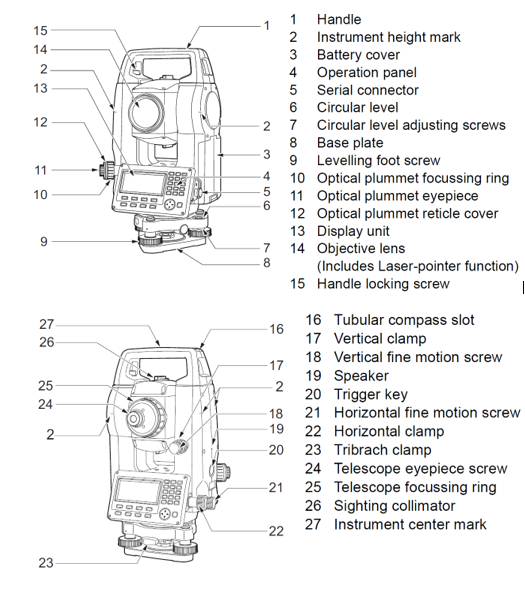

## Setting up the Total Station

### Centering

- **Step 1.** Make sure the legs are spaced at equal intervals and the head is approximately level. Set the tripod so that the head is positioned over the survey point. Make sure the tripod shoes are firmly fixed.

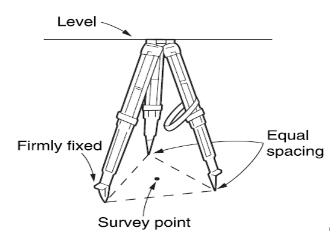

- **Step 2.** Place the instrument on the tripod head. Supporting it with one hand, tighten the centering screw on the bottom of the unit to make sure it is secured to the tripod.

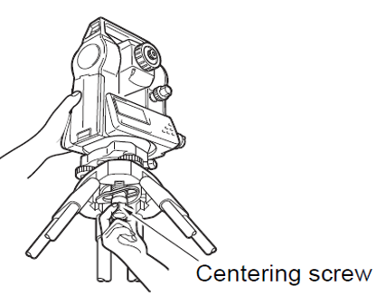

- **Step 3.** Looking through the optical plummet eyepiece, turn the optical plummet eyepiece to focus on the reticle. Turn the optical plummet focusing ring to focus on the survey point.

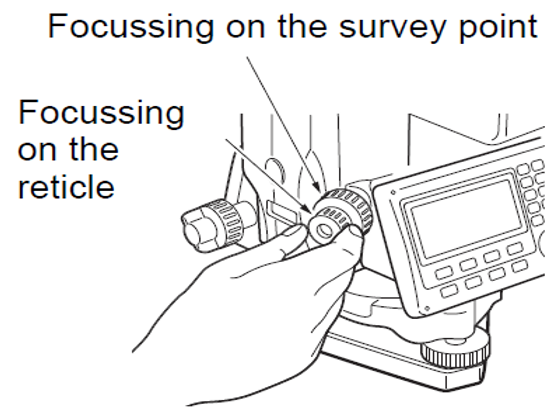

- **Step 4.** Adjust the leveling foot screws to center the survey point in the optical plummet reticle.

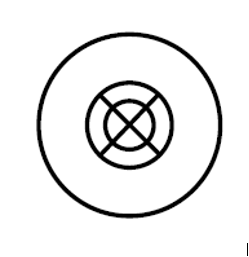

### Leveling

- **Step 1.** Center the bubble in the circular level by either shortening the tripod leg closest to the off-center direction of the bubble or by lengthening the tripod leg farthest from the off-center direction of the bubble. Adjust one more tripod leg to center the bubble. Turn the leveling foot screws while checking the circular level until the bubble is centered in the center circle.

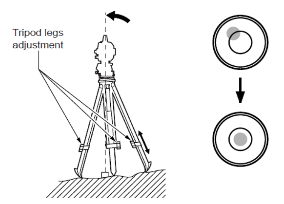

- **Step 2.** Power on the total station.

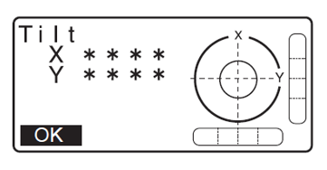

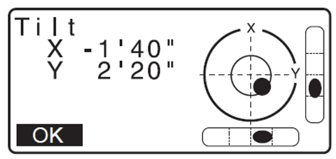

- **Step 4.** Turn the instrument until the telescope is parallel to a line between leveling foot screws A and B, then tighten the horizontal clamp.

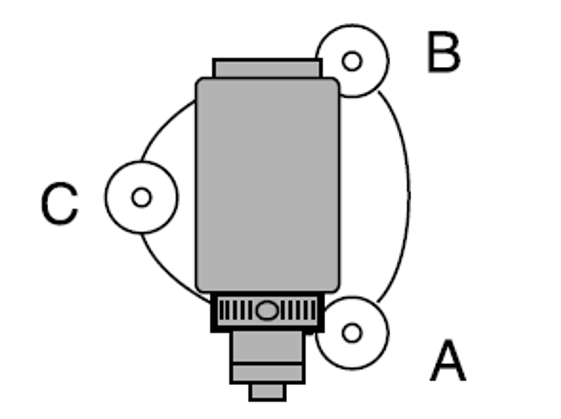

- **Step 5.** Set the tilt angle to 0° using foot screws A and B for the X direction and leveling screw C for the Y direction.
- **Step 6.** Loosen the centering screw slightly. Looking through the optical plummet eyepiece, slide the instrument over the tripod head until the survey point is exactly centered in the reticle. Retighten the centering screw securely.
- **Step 7.** Confirm that the bubble is positioned at the center of the circular level on the screen. If not, repeat the procedure starting from step 5.
- **Step 8.** When leveling is completed, press **[OK]** changes to the OBS mode.

### Survey Prism Offset:

−30mm (0.0984 ft)

### Azimuth:

Azimuth is defined as a horizontal angle measured clockwise from a north base line. Azimuth has also been more generally defined as a horizontal angle measured clockwise from any fixed reference plane or easily established base direction line.

In the figure below, the azimuth of line AB is known to be 137° 17’ 00" from the north. The azimuth of any other line that starts at A, such as AC in the figure, can be found directly using a total station instrument.

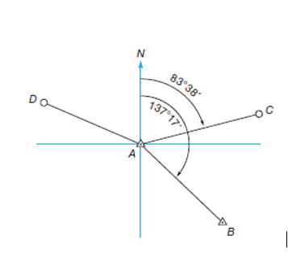

### Notations:

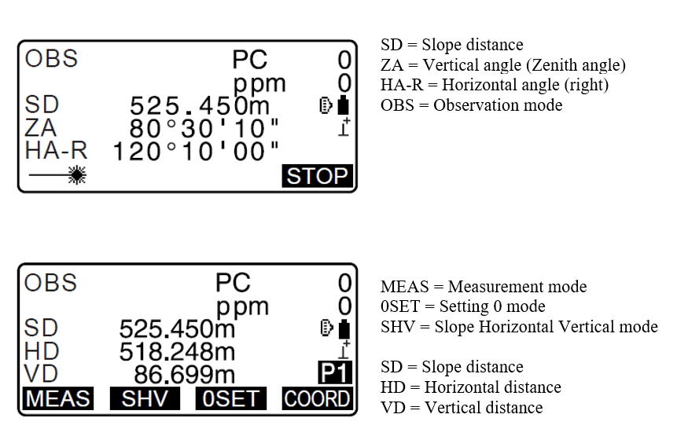

## Field Work

### Task 1: Distance and Angle Measurement

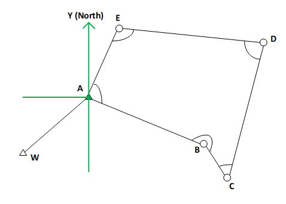

### Task 2: Field Book Entry of Distance and Angle Measurement

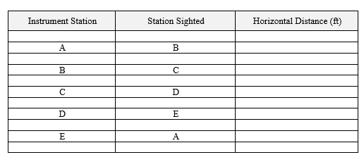

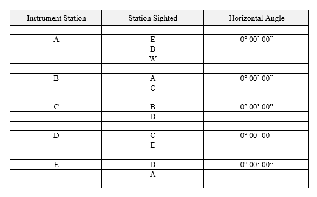